# **Statistical comparison between less social(IL) and more social(KI) groups of prairie vole base on their centrality measures from their pre-frontal cortex brain region**

Maths Application in Data Science Report One

George E. Quaye

gequaye@miners.utep.edu

University of Texas, El Paso (UTEP)Department of Mathematical Sciences

This study primarily provides statistical comparative analysis to an objective question to be answered between two groups of prairie voles by means of a network (neural network). The satellite region of interest from these prairie voles is the pre-frontal cortex region of their brain.

Numerous measures quantify the potential of individual nodes and edges to influence the global state of the network. Many of them allow the identification of network hubs, (Sporns, Honey, and Kötter 2007), (Heuvel and Sporns 2013), generally defined as highly central parts of the network. The number of connections maintained by a node (its degree centrality) often provides a strong indicator of influence or centrality. Other measures of centrality take advantage of the layout of the shortest paths within the network and record the number of such paths that pass through a given node or edge, this measure is called the betweenness centrality. Yet another way to approach centrality measure is closeness (or closeness centrality) of a node in a graph (network), which is estimated as the sum of the length of the shortest paths between the node and all other nodes in the graph. Also, comes another influential centrality measure called eigencentrality , which assigns relative scores to all nodes in the network based on the concept that connections to high-scoring nodes contribute more to the score of the node in question than equal connections to low-scoring nodes.

However, most measures of node centrality are mutually related (and hence statistically correlated); for example, in most (but not all) networks nodes with many connections (high degree) also serve as intermediaries on many short paths (high betweenness). Since different measures of centrality index different aspects of network organization, it can be beneficial to rank nodes by aggregating multiple centrality measures.(Sporns, Honey, and Kötter 2007)

The main objective of this analysis then is to justify statistically that, given these centrality measures from the pre-frontal cortex region of the brain in the IL and KI voles, we can strongly confirm that there is a significant difference in their social behavior as indicated.

In this section a network graph is obtained for groups and connectivity for the pre-frontal cortex region is clearly seen graphical amongst all other regions. A boxplot and a density plot are generated to compare the centrality measures from the IL and KI groups specific to the pre-frontal cortex region. A boxplot is a standardized way of displaying the distribution of data based on a five-number summary (“minimum”, first quartile (Q1), median, third quartile (Q3), and “maximum”) for these centrality measures. Also, a probability density plot is used to further assess the distribution of the sample centrality measure for further analysis.

The prairie vole (Microtus ochrogaster) is a socially monogamous rodent that forms long-term pair-bond between breeding pairs, which provides a unique model to characterize functionality in this network associated with social commitment (Aragona and Wang, 2004). The prairie vole has been used for over three decades to study the neurobiology of pair bonding, which has led to well-defined behavioral characterization of the commitment signals of the pair bond, including partner affiliation and stranger aggression (Smith et al., 2013). This creates an ethologically valid model to measure social behaviors that constitute the behavioral expression of a pair bond. Furthermore, a number of brain regions in the SDMN have been individually identified to be involved in the regulation of partner affiliation, stranger aggression, or both in prairie voles (Walum and Young, 2018).

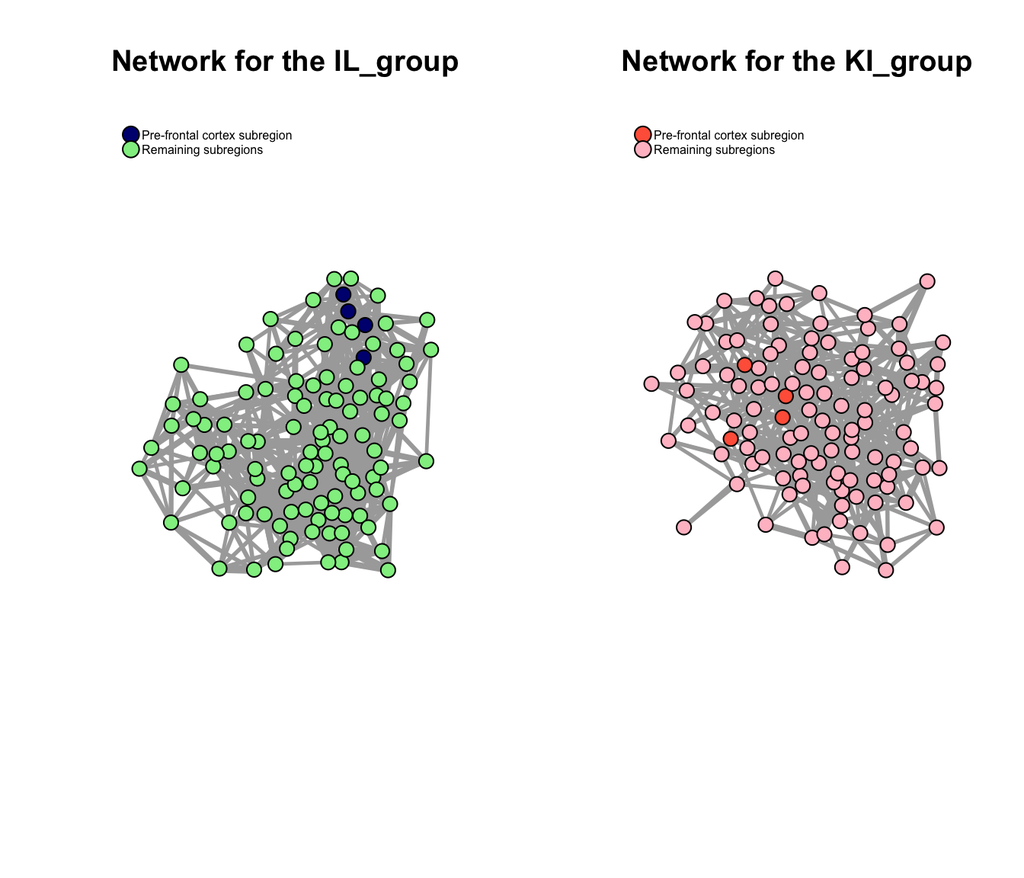

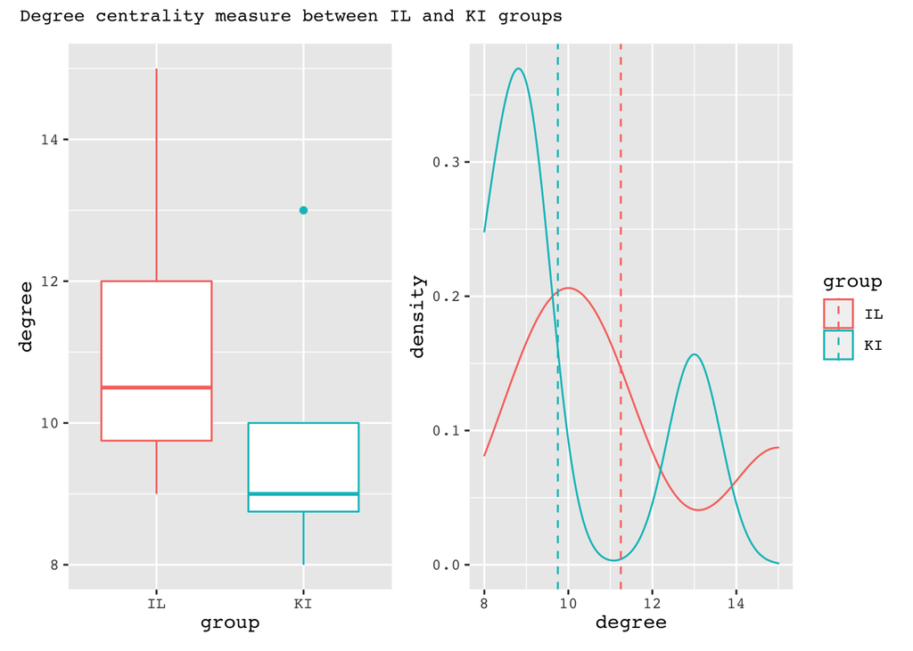

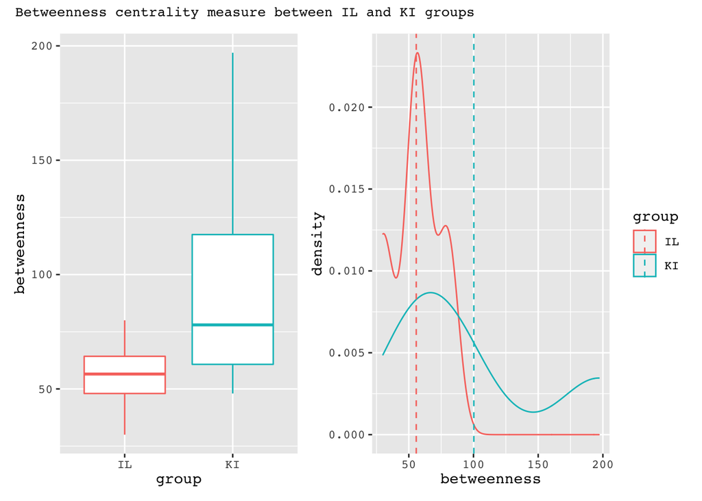

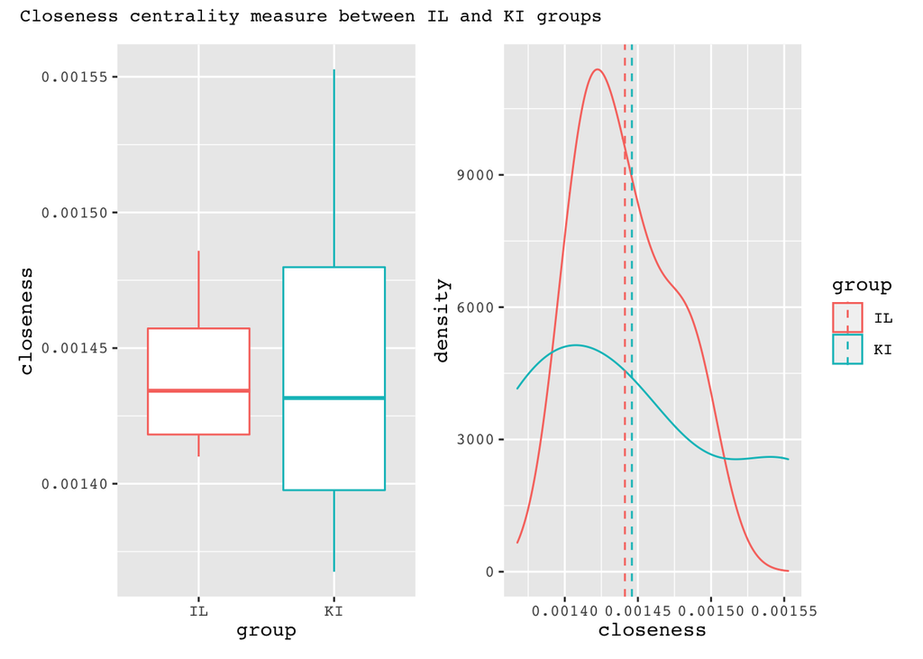

Given the plot of closeness centrality between the two groups, we observe that there is greater variability in KI group area_average to the KI group. The KI group has the highest and least closeness observation between the two groups given the connectivity of the prefrontal cortex to others. On average from the boxplot, the closeness measure from the IL group is somehow equal to the KI group as it is also depicted in the graph density plot by the vertical dash lines. However, the two samples’ closeness measures have some kind of skewed distribution, that is they are not normally distributed as shown in the density plot. Since the notches in the boxplots somewhere tend to overlap as well as the dash lines, one can graphically conclude that with some certainty but not dully 95% confidence, the true averages do not differ. An accurate statistical analysis is required to accept this graphical conclusion.

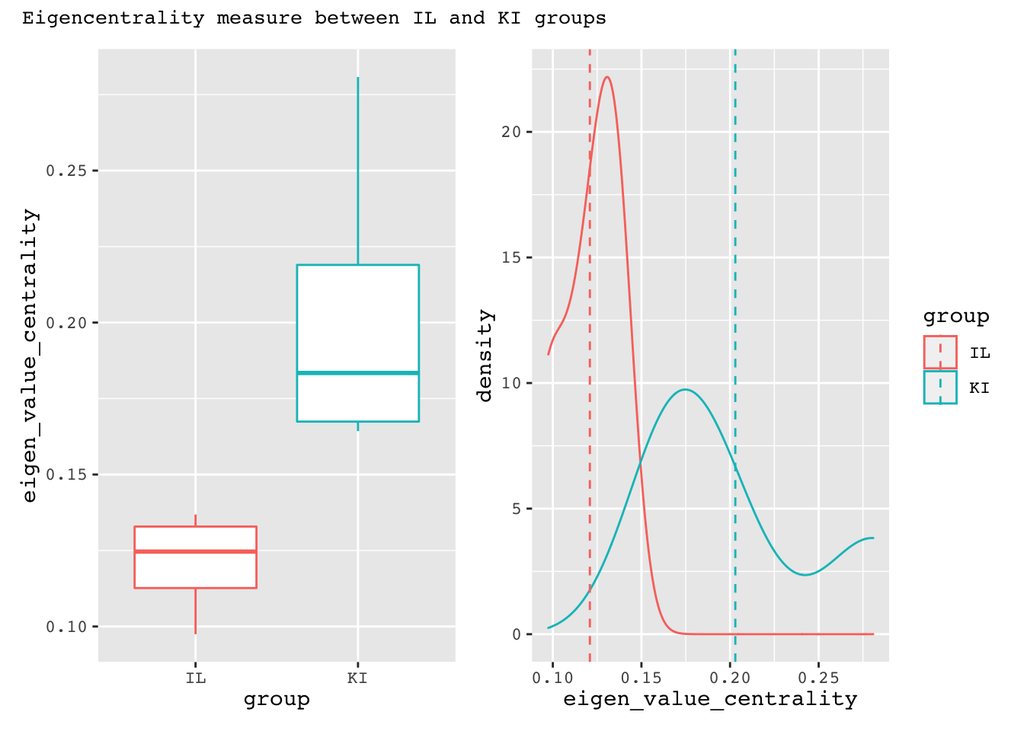

Given the plot of eigencentrality between the two groups, we observe that there is greater variability in KI group area_average to the KI group. The minimum value of the KI group is still higher than the maximum value or observation of the IL group from the pre-frontal cortex region. On average from the boxplot, the eigencentrality measure from the KI group is much greater than the IL group as it is also depicted in the graph density plot by the vertical dash lines. The two samples have skewed distribution, that is they are not normally distributed as clearly shown in the density plot. Again, since the notches in the boxplots do not overlap as well as the dash lines, one can graphically conclude that with 95% confidence, the true averages do differ. Statistical analysis will further be used to confirm this.

After the exploratory analysis and graphical conclusions, one could say given centrality measure such as the degree, the betweenness, and the eigencentrality the two groups differ. However, such a conclusion can only be concrete after a suitable and accurate test is carried out on each measure between the two groups. Given the descriptive plots above it was clearly seen that the sample measure was not normally distributed, hence, a non-parametric comparison between the two groups is appropriate. Therefore, using the Mann-Whitney-Wilcoxon Test, we can decide whether the centrality measures from the pre-frontal cortex region of the brain for each group distribution are identical without assuming them to follow the normal distribution.

*Assumptions*

- This test does not rely on assumption that the data are drawn from a normal distribution, thus the use of variance becomes meaningless. This is clearly shown by the density plots and boxplots.
- The two data samples are independent if they come from distinct populations and the samples do not affect each other. This is verified becomes the measure comes from the two distinct groups IL and KI. That is they are unpaired data samples.

For the purpose of comparison and uniformity all statistical test involving the four centrality measures is subject to the follow;

*Problem*

Without assuming the data to have normal distribution, decide at .05 significance level if there is a significant difference between less social (IL) and more social (KI) groups of voles based on their centrality measures estimated.

- $\alpha$ = 0.05 this is the critical region
- $n_{IL}$= 4 sample size for the IL group for the Pre-frontal cortex region
- $n_{KI}$ = 4 sample size for the IL group for the Pre-frontal cortex region
- $n_{IL} + n_{KI}$ = 8 , total sample size

*Hypothesis*

- $H_{0}$ = There is no significant difference between less social (IL) and more social (KI) groups of voles based on their centrality measures estimated.
- $H_{1}$ = There is a significant difference between less social (IL) and more social (KI) groups of voles based on their centrality measures estimated.

*Decision rule*

- Reject the null hypothesis ($H_{0}$) if the wilcoxon $P_{value}$ $<$ $\alpha$= 0.05.

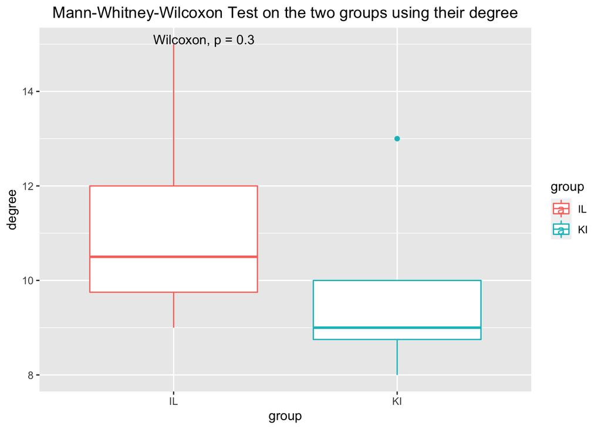

In the statistical analysis by the Mann Whitney test, the p-values turn out to be 0.3, which is greater than the 0.05 significance level, hence we fail to reject the null hypothesis. There is insufficient evidence at 0.05 significance level to conclude that, based on the degree centrality there is a significant difference between less social (IL) and more social (KI) groups of voles given their pre-frontal corte.

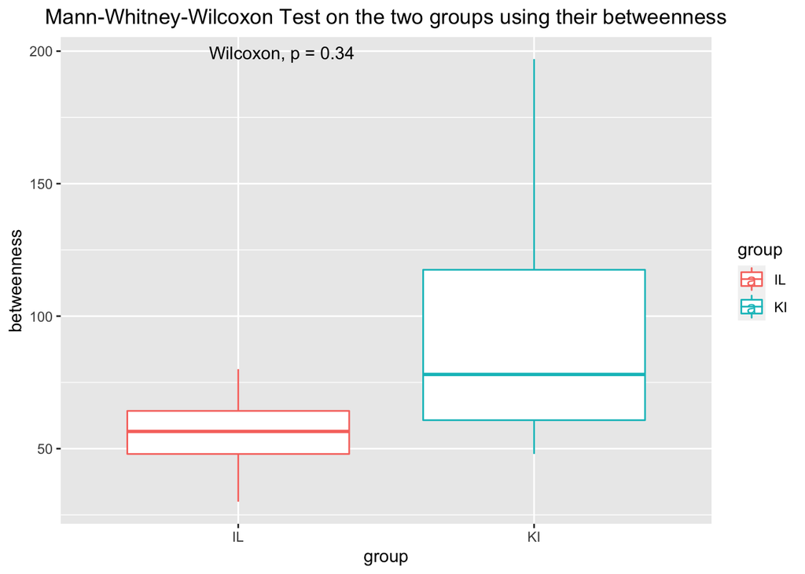

In the statistical analysis by the Mann Whitney test, the p-value from the test of betweenness turn out to be 0.34 which is greater than the 0.05 significance level, hence we fail to reject the null hypothesis. There is insufficient evidence at 0.05 significance level to conclude that, based on the betweenness centrality there is a statistically significant difference between less social (IL) and more social (KI). groups of voles given their pre-frontal corte.

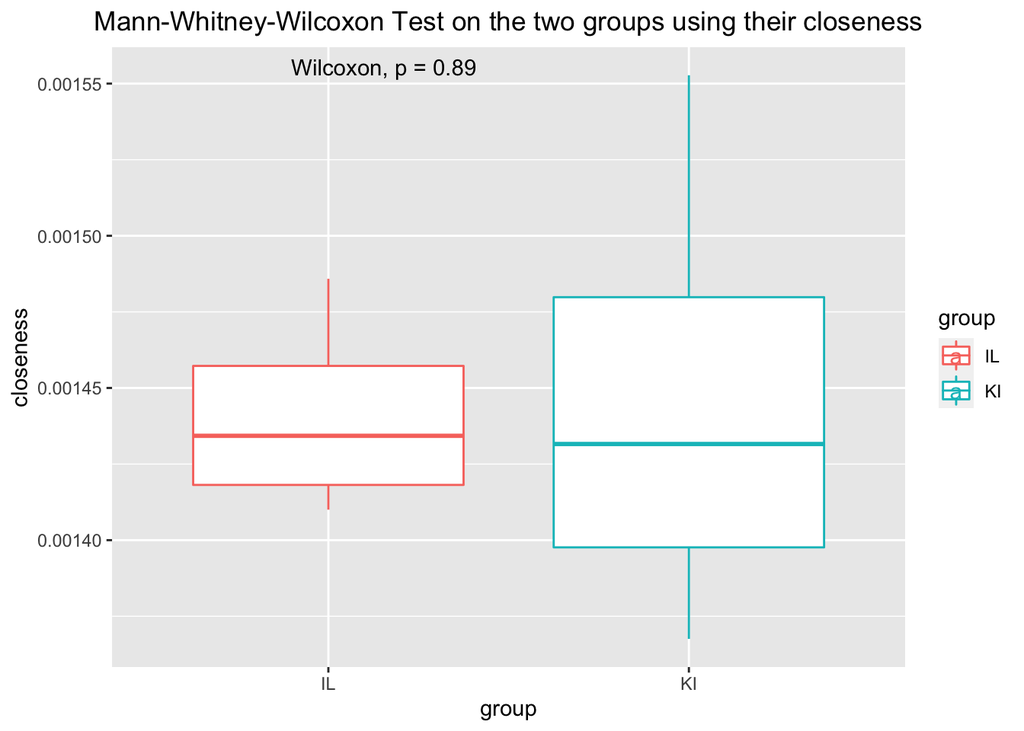

The Mann-Whitney test for the closeness centrality between the groups, the p-value from the test turns out to be 0.89 which is greater than the 0.05 significance level, hence we fail to reject the null hypothesis. There is insufficient evidence at 0.05 significance level to conclude that, based on the closeness centrality there is a statistically significant difference between less social (IL) and more social (KI). groups of voles given their pre-frontal cortex.

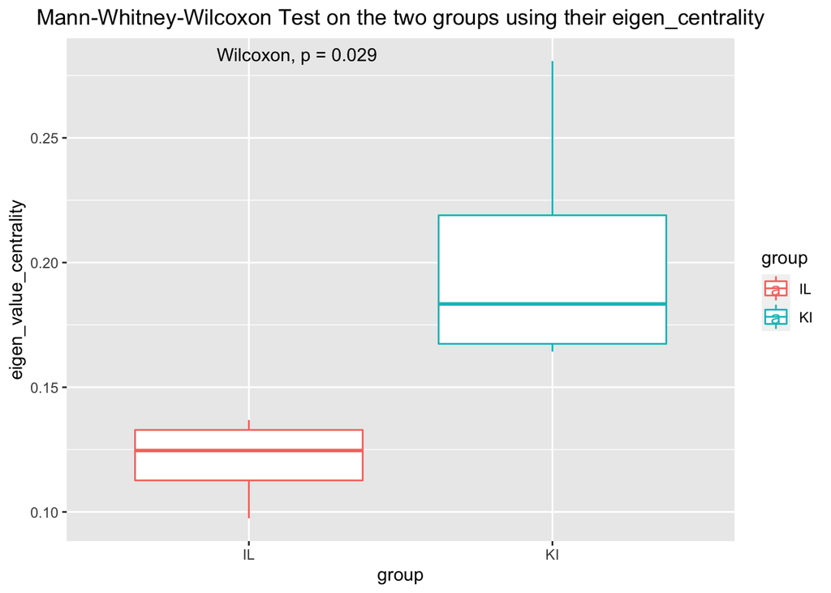

The Mann-Whitney test for the Eigen centrality between the groups, the p-value from the test turns out to be 0.029 which is less than the 0.05 significance level, hence we reject the null hypothesis. There is sufficient evidence at a 0.05 significance level to conclude that, based on the Eigen centrality there is a statistically significant difference between the less social (IL) and the more social (KI). groups of voles given their pre-frontal cortex.